# Investigación reproducible y github

01/09, 2025

## Que es la investigación reproducible?

- Código, datos (**Crudos**) y texto entrelazados
- en R: Rmarkdown (Rmd)

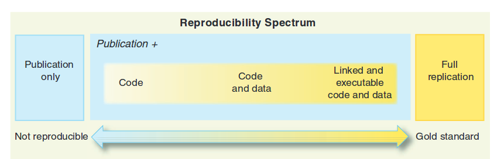

## Github

## Github

- Como “Google Drive” o “Dropbox” para código
- Control de cambios (Podemos volver a cualquier versión anterior)
- En base a codigo (idealmente), pero hay GUIs
- Cada proyecto es un repositorio

[figure not shown]

## Crear primer repositorio

- Crearse cuenta en github.com
- Crear repositorio en github

[figure not shown]

## Crear primer repositorio

[figure not shown]

## Copiar la url

[figure not shown]

## Volvamos a RStudio

- Creamos un proyecto nuevo

[figure not shown]

## Pegamos la URL

[figure not shown]

## La nueva pestaña git

[figure not shown]

## Los “¿tres?” pasos de un repositorio

- **Git add:** Agregar a los archivos que vas a guardar
- **Git commit:** Guardar en el repositorio local (Mi computador)
- **Git push:** Guardar en el repositorio remoto (En la nube)
- Otros como git merge, git pull, git clone, etc

## Git Add

- Sumar un archivo al repositorio
- ¿Cuando no hacerlo?
  - Limite de un archivo de 100 Mb
  - Límite de un repositorio de un Gb

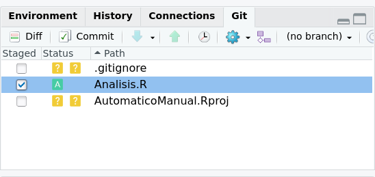

## Git commit

- Con esto dices quiero guardar mis cambios en mi disco duro
- Se guarda en tu repositorio local (Tu computador)

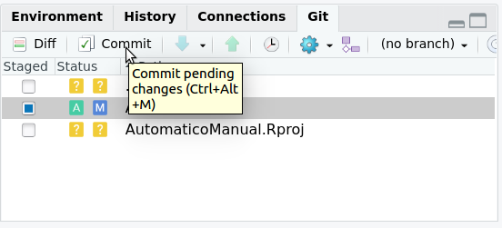

## Mensaje del commit

- Debe ser relevante (ejemplo, no poner *Version final ahora si*)
- Si te equivocas puedes restablecer a cualquier commit anterior (si sabes cual es)

[figure not shown]

## A guardar el repositorio (git push)

- Con esto subes tu commit a la nube (queda respaldado)

[figure not shown]

## Configurar github

```r
git config --global user.name "derek-corcoran-barrios"
git config --global user.email "derek-corcoran-barrios@gmail.com"
```

## Si no resulta

- Si estas en windows instala [git](https://git-scm.com/download/win)
- Si estas en mac
- Si estas en linux

```r
sudo apt-get update
sudo apt-get install git
```

## Dudas?

## Reproducibilidad en R

[figure not shown]

1. Una carpeta
   - Datos crudos (csv, xls, html, json)
   - Codigo y texto (Rmd, Rpres, shiny)
   - Resultados (Manuscrito, Pagina Web, App)

## Antes de empezar (importar datos)

- Hasta ahora hemos usado `data` (sólo para bases incorporadas en R)
- Desde hoy usaremos `read_csv` (Para csv, para otros archivos hay otras funciones)
- Otro tipo de datos son los `.rds`, todo puede ser transformado a este formato

## Datos para trabajar

- Puedes hacer:

```r
library(readr)
plants <- read_csv("https://raw.githubusercontent.com/rfordatascience/tidytuesday/master/data/2020/2020-08-18/plants.csv")
```

o

```r
plants <- readr::read_csv("https://raw.githubusercontent.com/rfordatascience/tidytuesday/master/data/2020/2020-08-18/plants.csv")
```

## Crear un nuevo Rmarkdown

[figure not shown]

## Esta vez usaremos un template de un `github document`

## Partes de un Rmd

1. Texto
2. Chunks
3. Inline code
4. [Cheat sheet Rmd](https://www.rstudio.com/wp-content/uploads/2015/02/rmarkdown-cheatsheet.pdf) (torpedo)
5. El botón mágico **Knit**

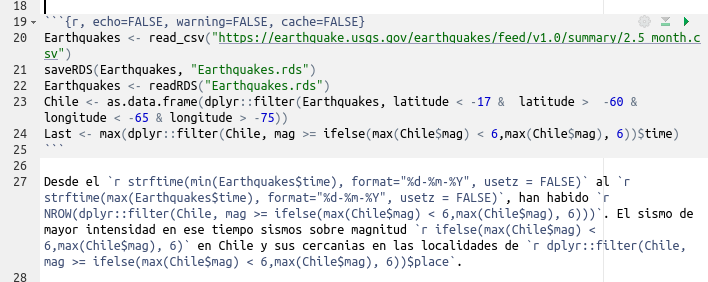

## Texto (sintáxis de markdown)

```r
# Titulo

## subtitulo

*cursiva*

**negrita**

[link](https://stackoverflow.com/users/3808018/derek-corcoran)
```

## Chunks

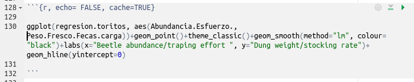

## Ejemplo 1

## Elijamos solo plantas de Chile

- En nuestro Rmd hagamos un data.frame solo con plantas de chile
- Elijamos solo las columnas de especie

## Ejemplo 2

- En nuestro Rmd hagamos un data.frame resumen, de número de plantas extintas por país de America del Sur
- Ahora subamoslo a github